# Association Rule Mining

# Association Rule Mining

The purpose of association rule mining is to reveal entities that frequently occur together. We see this type of application in:

1. market basket analysis: what types of products do people tend to purchase together?
2. recommendation systems: people who bought book A also bought book B…

# Data

The Mr. A’s Data Set

| Chicken | Ice Cream | Tacos |
| --- | --- | --- |
| 0 | 1 | 1 |
| 1 | 0 | 1 |
| 1 | 0 | 1 |
| 1 | 0 | 1 |
| 0 | 0 | 1 |
| 0 | 1 | 0 |
| 1 | 0 | 1 |
| 1 | 0 | 1 |
| 0 | 1 | 0 |
| 0 | 0 | 1 |

# Typical Metrics

## Support

Support measures how frequently two (or more) items appear together. Support is the number of times a specific item appears in a transaction divided by the total number of transactions.

The support for chicken is: $supp(c) = 5/10 = .5$

We can also calculate the support of two or more items: $supp(x \cup y)$

The support for chicken and tacos is: $supp(c \cup t) = 5/10 = .5$

## Confidence

Confidence measures the likelihood that a transaction includes item Y given that the transaction includes item X.

$conf(x \implies y) = supp(x \cup y)/supp(x)$

The confidence of $conf(c \implies t) = supp(c \cup t)/supp(c) = .5/.5 = 1$

In other words, every time someone purchased chicken she or he also purchased tacos.

Since association rule mining produces many, many rules, we use support and confidence to filter the rules representing combinations that occur too infrequently or with too little confidence to be useful.

## Lift

We also need a way to gauge whether the rules we generate happen by chance or represent a statistically significant effect in our data.

$lift(x \implies y) = supp(x \cup y)/supp(x) * supp(y)$

For example, $lift(c \implies t) = supp(c \cup t)/supp(c) * supp(t) = .5/.4 = 1.25$

Values close to 1 represent rules without much statistical significance. Values larger than 1 represent rules not likely to have occurred by chance.

# Analyzing Association Rules in R

## Example 1: Mr A’s.

Let’s review the analysis above in R.

```r
data <- read.csv("in-class_mras.csv")
data
```

```
##    Chicken Ice.Cream Tacos
## 1        0         1     1
## 2        1         0     1
## 3        1         0     1
## 4        1         0     1
## 5        0         0     1
## 6        0         1     0
## 7        1         0     1
## 8        1         0     1
## 9        0         1     0
## 10       0         0     1
```

We need to treat the data to prepare it for analysis. In this context, we need to convert our numeric data into logical types representing true or false.

```r
for (i in 1:3){
    data[,i] <- as.logical(data[,i])
}
data
```

```
##    Chicken Ice.Cream Tacos
## 1    FALSE      TRUE  TRUE
## 2     TRUE     FALSE  TRUE
## 3     TRUE     FALSE  TRUE
## 4     TRUE     FALSE  TRUE
## 5    FALSE     FALSE  TRUE
## 6    FALSE      TRUE FALSE
## 7     TRUE     FALSE  TRUE
## 8     TRUE     FALSE  TRUE
## 9    FALSE      TRUE FALSE
## 10   FALSE     FALSE  TRUE
```

Now the data are properly prepared for analysis so we can load our libraries and get to work.

```r
library("arules")
```

```r
trans <- as(data, "transactions")
image(trans)
```

[output not shown]

The `apriori()` command takes our transactions and returns the association rule list for all rules with confidence and support greater than 0. In other words, this command will return all possible rules. We then sort the rules by the lift metric. Finally, we review the sorted rules with the `inspect()` command.

```r
rules <- apriori(trans, parameter=list(conf=0.0,supp=0.0))
```

```
## Apriori
##
## Parameter specification:
##  confidence minval smax arem  aval originalSupport support minlen maxlen
##           0    0.1    1 none FALSE            TRUE       0      1     10
##  target   ext
##   rules FALSE
##
## Algorithmic control:
##  filter tree heap memopt load sort verbose
##     0.1 TRUE TRUE  FALSE TRUE    2    TRUE
##
## Absolute minimum support count: 0
```

```
## set item appearances ...[0 item(s)] done [0.00s].
## set transactions ...[3 item(s), 10 transaction(s)] done [0.00s].
## sorting and recoding items ... [3 item(s)] done [0.00s].
## creating transaction tree ... done [0.00s].
## checking subsets of size 1 2 done [0.00s].
## writing ... [9 rule(s)] done [0.00s].
## creating S4 object  ... done [0.00s].
```

```r
rules.sorted <- sort(rules, by="lift")
inspect(rules.sorted)
```

```
##   lhs            rhs         support confidence lift
## 8 {Chicken}   => {Tacos}     0.5     1.0000000  1.2500000
## 9 {Tacos}     => {Chicken}   0.5     0.6250000  1.2500000
## 1 {}          => {Ice.Cream} 0.3     0.3000000  1.0000000
## 2 {}          => {Chicken}   0.5     0.5000000  1.0000000
## 3 {}          => {Tacos}     0.8     0.8000000  1.0000000
## 7 {Tacos}     => {Ice.Cream} 0.1     0.1250000  0.4166667
## 6 {Ice.Cream} => {Tacos}     0.1     0.3333333  0.4166667
## 4 {Ice.Cream} => {Chicken}   0.0     0.0000000  0.0000000
## 5 {Chicken}   => {Ice.Cream} 0.0     0.0000000  0.0000000
```

In most cases, we will want to filter our results with confidence and support. Let’s take a look at rules with a support of 0.25 or greater and a confidence of .5 or greater.

```r
rules <- apriori(trans, parameter=list(conf=0.5,supp=0.25))
```

```
## Apriori
##
## Parameter specification:
##  confidence minval smax arem  aval originalSupport support minlen maxlen
##         0.5    0.1    1 none FALSE            TRUE    0.25      1     10
##  target   ext
##   rules FALSE
##
## Algorithmic control:
##  filter tree heap memopt load sort verbose
##     0.1 TRUE TRUE  FALSE TRUE    2    TRUE
##
## Absolute minimum support count: 2
##
## set item appearances ...[0 item(s)] done [0.00s].
## set transactions ...[3 item(s), 10 transaction(s)] done [0.00s].
## sorting and recoding items ... [3 item(s)] done [0.00s].
## creating transaction tree ... done [0.00s].
## checking subsets of size 1 2 done [0.00s].
## writing ... [4 rule(s)] done [0.00s].
## creating S4 object  ... done [0.00s].
```

```r
rules.sorted <- sort(rules, by="lift")
inspect(rules.sorted)
```

```
##   lhs          rhs       support confidence lift
## 3 {Chicken} => {Tacos}   0.5     1.000      1.25
## 4 {Tacos}   => {Chicken} 0.5     0.625      1.25
## 1 {}        => {Chicken} 0.5     0.500      1.00
## 2 {}        => {Tacos}   0.8     0.800      1.00
```

## Example 2: Voting Behavior

We can analyze the voting behavior of politicians with this technique. The following data represents the voting behavior of 435 congressional members for 16 key votes identified by the Congressional Quarterly Almanac.

http://archive.ics.uci.edu/ml/datasets/Congressional+Voting+Records

This data is more complex than our previous example and requires a good deal more cleansing and preparation.

## Load the data

```r
data <- read.table("https://archive.ics.uci.edu/ml/machine-learning-databases/voting-records/house-votes-84.data", sep=",")
```

## Cleanse the data

```r
sdata <- data
sdata$republican <- 0
sdata$republican[sdata[,"V1"]=="republican"] <- 1
sdata$democrat <- 0
sdata$democrat[sdata[,"V1"]=="democrat"] <- 1
```

The code above creates new fields representing republic and democratic party members.

By default, R will assign variable names in the format V1, V2, etc. Since we want to interpret which legislation representatives tend to support together, we want to format the column names to represent our meaningful names.

```r
names(sdata) <- c("party","handicapped-infants",
                  "water-project-cost-sharing",
                  "adoption-of-the-budget-resolution",
                  "physician-fee-freeze",
                  "el-salvador-aid",
                  "religious-groups-in-schools",
                  "anti-satellite-test-ban",
                  "aid-to-nicaraguan-contras",
                  "mx-missile",
                  "immigration",
                  "synfuels-corporation-cutback",
                  "education-spending",
                  "superfund-right-to-sue",
                  "crime",
                  "duty-free-exports",
                  "export-administration-act-south-africa",
                  "republican",
                  "democrat")
```

## Cluster voting behavior

While we are handling categorical data, let’s see how we might cluster these data. We need to create a matrix in which we make all values zero. Then anything representing a yes vote, we convert to ones.

```r
library("proxy")
ndata <- matrix(0,nrow=435,ncol=16)
for(i in 2:17){
    ndata[sdata[,i]=="y",(i-1)] <- 1
}
```

This means that we can construct a distance matrix using the cosine distance which is a reasonable choice for these kinds of data. We can use this to construct a dendrogram.

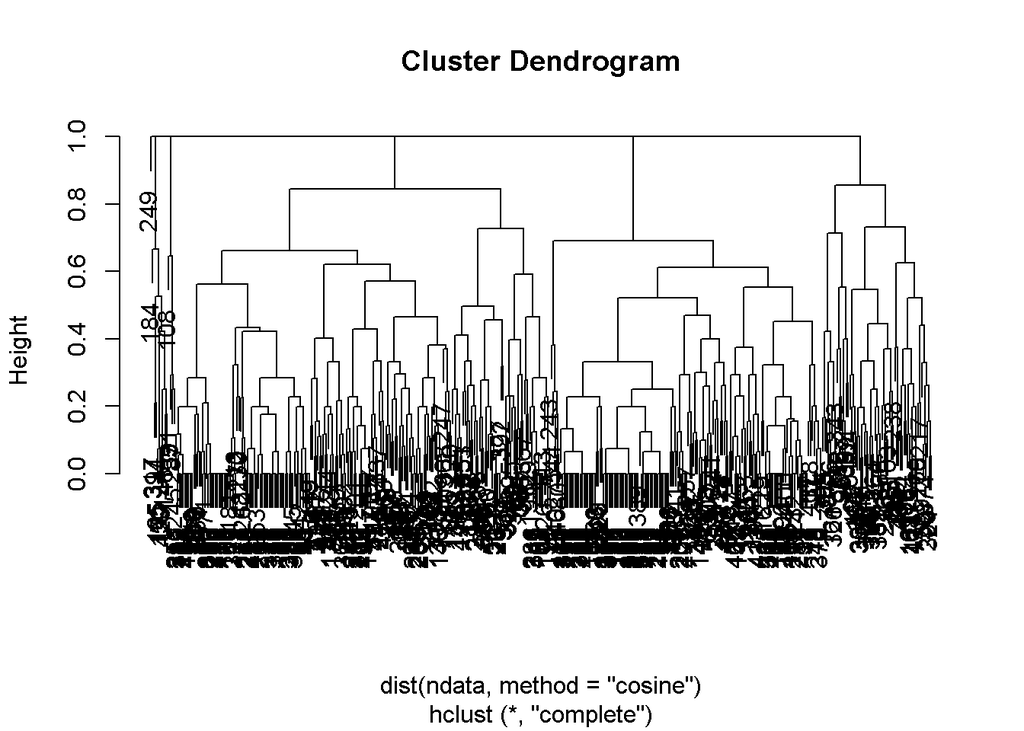

```r
hc <- hclust(dist(ndata, method="cosine"))
plot(hc)
```

We can also use the `cluster` library to create clusters with special distances like the cosine distance.

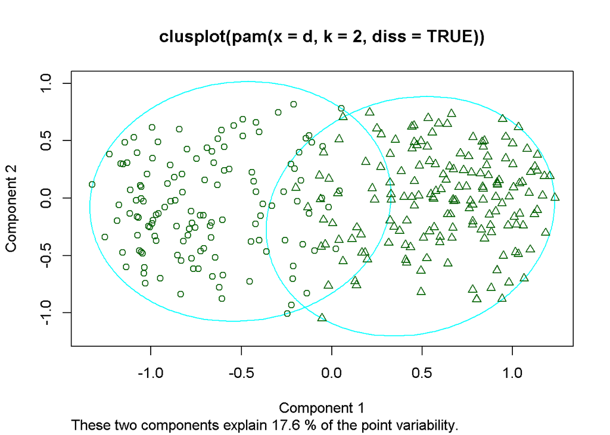

```r
library(cluster)
d <- dist(ndata, method="cosine")
pc <- pam(d, 2, diss=TRUE)
clusplot(pc)
```

## Back to Association Rules

We join our data to the original party labels for convenience.

```r
tdata <- cbind(sdata[,1],ndata, sdata[,18:19])
```

Add the names to our new data frame.

```r
names(tdata) <- c("party","handicapped-infants",
                  "water-project-cost-sharing",
                  "adoption-of-the-budget-resolution",
                  "physician-fee-freeze",
                  "el-salvador-aid",
                  "religious-groups-in-schools",
                  "anti-satellite-test-ban",
                  "aid-to-nicaraguan-contras",
                  "mx-missile",
                  "immigration",
                  "synfuels-corporation-cutback",
                  "education-spending",
                  "superfund-right-to-sue",
                  "crime",
                  "duty-free-exports",
                  "export-administration-act-south-africa",
                  "republican",
                  "democrat")
```

We convert all of our data to logical data types.

```r
for(i in 2:19){
    tdata[,i] <- as.logical(tdata[,i])
}
```

We convert our data to transactions.

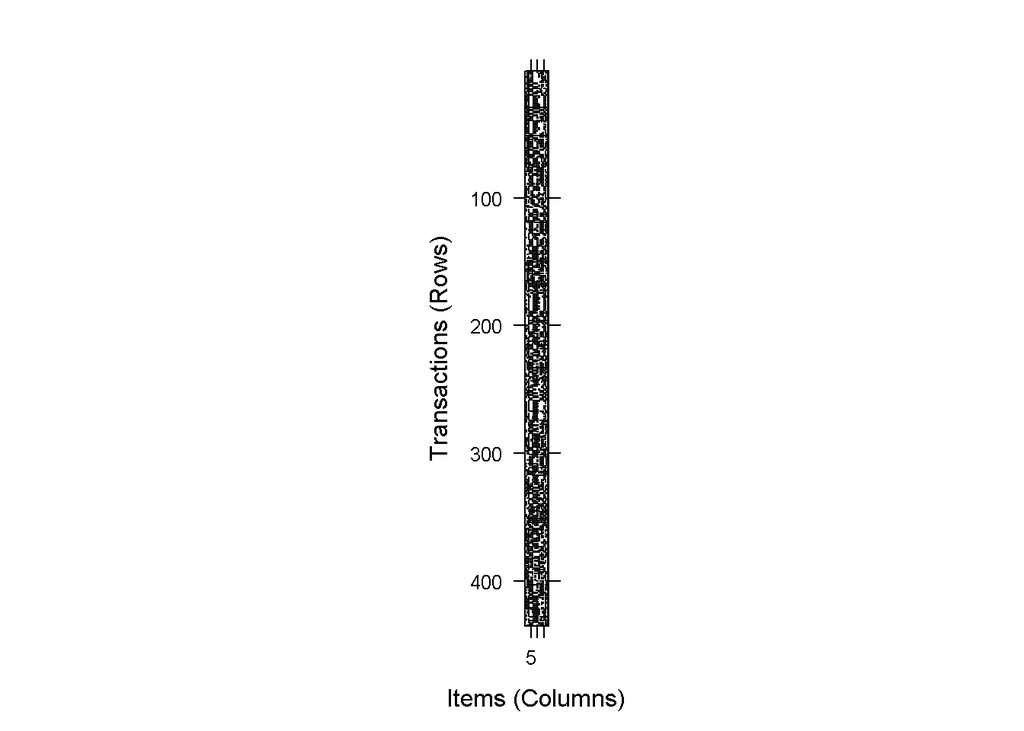

```r
trans <- as(tdata[,2:19], "transactions")
image(trans)
```

Finally, we can generate our rules. We only want to see rules with a minimum support of .3 and minimum confidence of .95. We also want to look at rules with democrat and republican on the right hand side of our rule set. In other words, we want to know how reliably a set of votes helps us predict a party. We could easily adjust this to focus on other types of issues.

```r
rules <- apriori(trans, parameter=list(conf=.95,supp=.3),
                 appearance=list(rhs=c("democrat","republican"),
                                 default="lhs"))
```

```
## Apriori
##
## Parameter specification:
##  confidence minval smax arem  aval originalSupport support minlen maxlen
##        0.95    0.1    1 none FALSE            TRUE     0.3      1     10
##  target   ext
##   rules FALSE
##
## Algorithmic control:
##  filter tree heap memopt load sort verbose
##     0.1 TRUE TRUE  FALSE TRUE    2    TRUE
##
## Absolute minimum support count: 130
##
## set item appearances ...[2 item(s)] done [0.00s].
## set transactions ...[18 item(s), 435 transaction(s)] done [0.00s].
## sorting and recoding items ... [18 item(s)] done [0.00s].
## creating transaction tree ... done [0.00s].
## checking subsets of size 1 2 3 4 5 done [0.00s].
## writing ... [8 rule(s)] done [0.00s].
## creating S4 object  ... done [0.00s].
```

```r
rules.sorted <- sort(rules, by="lift")
inspect(rules.sorted)
```

```
##   lhs                                    rhs            support confidence     lift
## 1 {physician-fee-freeze,
##    education-spending}                => {republican} 0.3080460  0.9503546 2.460740
## 2 {adoption-of-the-budget-resolution,
##    anti-satellite-test-ban,
##    aid-to-nicaraguan-contras,
##    mx-missile}                        => {democrat}   0.3448276  0.9677419 1.576658
## 3 {adoption-of-the-budget-resolution,
##    aid-to-nicaraguan-contras,
##    mx-missile}                        => {democrat}   0.3793103  0.9649123 1.572048
## 4 {adoption-of-the-budget-resolution,
##    aid-to-nicaraguan-contras,
##    duty-free-exports}                 => {democrat}   0.3057471  0.9637681 1.570184
## 5 {aid-to-nicaraguan-contras,
##    duty-free-exports}                 => {democrat}   0.3333333  0.9602649 1.564477
## 6 {adoption-of-the-budget-resolution,
##    anti-satellite-test-ban,
##    mx-missile}                        => {democrat}   0.3540230  0.9565217 1.558378
## 7 {adoption-of-the-budget-resolution,
##    duty-free-exports}                 => {democrat}   0.3310345  0.9536424 1.553687
## 8 {adoption-of-the-budget-resolution,
##    mx-missile}                        => {democrat}   0.3931034  0.9500000 1.547753
```

## Additional Analysis

We can explore the size and distribution of transactions.

```r
summary(rules)
```

```
## set of 8 rules
##
## rule length distribution (lhs + rhs):sizes
## 3 4 5
## 4 3 1
##
##    Min. 1st Qu.  Median    Mean 3rd Qu.    Max.
##   3.000   3.000   3.500   3.625   4.000   5.000
##
## summary of quality measures:
##     support         confidence          lift
##  Min.   :0.3057   Min.   :0.9500   Min.   :1.548
##  1st Qu.:0.3253   1st Qu.:0.9528   1st Qu.:1.557
##  Median :0.3391   Median :0.9584   Median :1.567
##  Mean   :0.3437   Mean   :0.9584   Mean   :1.675
##  3rd Qu.:0.3603   3rd Qu.:0.9641   3rd Qu.:1.573
##  Max.   :0.3931   Max.   :0.9677   Max.   :2.461
##
## mining info:
##   data ntransactions support confidence
##  trans           435     0.3       0.95
```

```r
summary(size(trans))
```

```
##    Min. 1st Qu.  Median    Mean 3rd Qu.    Max.
##   1.000   8.000   9.000   8.864  10.000  14.000
```

We can also explore other measures of interest. In particular, we can use Fishers Exact Test to confirm that the results we have are statistically significant. Fishers Exact Test provides the same information as lift, but expresses that information in the p-value familiar to other statistical procedures. As an aside, Fishers Exact Test is used to confirm that differentially expressed genes are statistically significant.

```r
measures <- interestMeasure(rules, measure=c("coverage","support","fishersExactTest","confidence","lift"),
                             transactions=trans)
summary(measures)
```

```
##     coverage         support       fishersExactTest      confidence
##  Min.   :0.3172   Min.   :0.3057   Min.   :0.000e+00   Min.   :0.9500
##  1st Qu.:0.3414   1st Qu.:0.3253   1st Qu.:0.000e+00   1st Qu.:0.9528
##  Median :0.3517   Median :0.3391   Median :1.540e-34   Median :0.9584
##  Mean   :0.3586   Mean   :0.3437   Mean   :3.664e-30   Mean   :0.9584
##  3rd Qu.:0.3759   3rd Qu.:0.3603   3rd Qu.:2.546e-31   3rd Qu.:0.9641
##  Max.   :0.4138   Max.   :0.3931   Max.   :2.836e-29   Max.   :0.9677
##       lift
##  Min.   :1.548
##  1st Qu.:1.557
##  Median :1.567
##  Mean   :1.675
##  3rd Qu.:1.573
##  Max.   :2.461
```

```r
measures.sorted <- measures[order(-measures$lift),]
inspect(rules.sorted)
```

```
##   lhs                                    rhs            support confidence     lift
## 1 {physician-fee-freeze,
##    education-spending}                => {republican} 0.3080460  0.9503546 2.460740
## 2 {adoption-of-the-budget-resolution,
##    anti-satellite-test-ban,
##    aid-to-nicaraguan-contras,
##    mx-missile}                        => {democrat}   0.3448276  0.9677419 1.576658
## 3 {adoption-of-the-budget-resolution,
##    aid-to-nicaraguan-contras,
##    mx-missile}                        => {democrat}   0.3793103  0.9649123 1.572048
## 4 {adoption-of-the-budget-resolution,
##    aid-to-nicaraguan-contras,
##    duty-free-exports}                 => {democrat}   0.3057471  0.9637681 1.570184
## 5 {aid-to-nicaraguan-contras,
##    duty-free-exports}                 => {democrat}   0.3333333  0.9602649 1.564477
## 6 {adoption-of-the-budget-resolution,
##    anti-satellite-test-ban,
##    mx-missile}                        => {democrat}   0.3540230  0.9565217 1.558378
## 7 {adoption-of-the-budget-resolution,
##    duty-free-exports}                 => {democrat}   0.3310345  0.9536424 1.553687
## 8 {adoption-of-the-budget-resolution,
##    mx-missile}                        => {democrat}   0.3931034  0.9500000 1.547753
```

## Alternative Formats

Transactional data can be presented in a number of formats. We can read these other formats as well when necessary.

For example, suppose we have transactional data in the following format.

```
Ice Cream,Tacos
Chicken,Tacos
Chicken,Tacos
Chicken,Tacos
Tacos
Ice Cream
Chicken,Tacos
Chicken,Tacos
Ice Cream
Tacos
```

We could read this data with the following command:

```r
trans_list <- read.transactions("in-class_mras_trans.csv",format="basket",sep=",")
image(trans_list)
```

[output not shown]

```r
new_rules <- apriori(trans_list, parameter=list(conf=0.0,supp=0.0))
```

```
## Apriori
##
## Parameter specification:
##  confidence minval smax arem  aval originalSupport support minlen maxlen
##           0    0.1    1 none FALSE            TRUE       0      1     10
##  target   ext
##   rules FALSE
##
## Algorithmic control:
##  filter tree heap memopt load sort verbose
##     0.1 TRUE TRUE  FALSE TRUE    2    TRUE
##
## Absolute minimum support count: 0
```

```
## set item appearances ...[0 item(s)] done [0.00s].
## set transactions ...[3 item(s), 10 transaction(s)] done [0.00s].
## sorting and recoding items ... [3 item(s)] done [0.00s].
## creating transaction tree ... done [0.00s].
## checking subsets of size 1 2 done [0.00s].
## writing ... [9 rule(s)] done [0.00s].
## creating S4 object  ... done [0.00s].
```

```r
new_rules.sorted <- sort(new_rules, by="lift")
inspect(new_rules.sorted)
```

```
##   lhs            rhs         support confidence lift
## 8 {Chicken}   => {Tacos}     0.5     1.0000000  1.2500000
## 9 {Tacos}     => {Chicken}   0.5     0.6250000  1.2500000
## 1 {}          => {Ice Cream} 0.3     0.3000000  1.0000000
## 2 {}          => {Chicken}   0.5     0.5000000  1.0000000
## 3 {}          => {Tacos}     0.8     0.8000000  1.0000000
## 7 {Tacos}     => {Ice Cream} 0.1     0.1250000  0.4166667
## 6 {Ice Cream} => {Tacos}     0.1     0.3333333  0.4166667
## 4 {Ice Cream} => {Chicken}   0.0     0.0000000  0.0000000
## 5 {Chicken}   => {Ice Cream} 0.0     0.0000000  0.0000000
```

Or we might see data like this.

```
1,Ice Cream,Tacos
2,Chicken,Tacos
3,Chicken,Tacos
4,Chicken,Tacos
5,Tacos
6,Ice Cream
7,Chicken,Tacos
8,Chicken,Tacos
9,Ice Cream
10,Tacos
```

We could read this data with the following command:

```r
trans_list <- read.transactions("mras_t.csv",format="basket",sep=",",
                                col=1)
image(trans_list)
```

[output not shown]

```r
new_rules <- apriori(trans_list, parameter=list(conf=0.0,supp=0.0))
```

```
## Apriori
##
## Parameter specification:
##  confidence minval smax arem  aval originalSupport support minlen maxlen
##           0    0.1    1 none FALSE            TRUE       0      1     10
##  target   ext
##   rules FALSE
##
## Algorithmic control:
##  filter tree heap memopt load sort verbose
##     0.1 TRUE TRUE  FALSE TRUE    2    TRUE
##
## Absolute minimum support count: 0
```

```
## set item appearances ...[0 item(s)] done [0.00s].
## set transactions ...[3 item(s), 10 transaction(s)] done [0.00s].
## sorting and recoding items ... [3 item(s)] done [0.00s].
## creating transaction tree ... done [0.00s].
## checking subsets of size 1 2 done [0.00s].
## writing ... [9 rule(s)] done [0.00s].
## creating S4 object  ... done [0.00s].
```

```r
new_rules.sorted <- sort(new_rules, by="lift")
inspect(new_rules.sorted)
```

```
##   lhs            rhs         support confidence lift
## 8 {Chicken}   => {Tacos}     0.5     1.0000000  1.2500000
## 9 {Tacos}     => {Chicken}   0.5     0.6250000  1.2500000
## 1 {}          => {Ice Cream} 0.3     0.3000000  1.0000000
## 2 {}          => {Chicken}   0.5     0.5000000  1.0000000
## 3 {}          => {Tacos}     0.8     0.8000000  1.0000000
## 7 {Tacos}     => {Ice Cream} 0.1     0.1250000  0.4166667
## 6 {Ice Cream} => {Tacos}     0.1     0.3333333  0.4166667
## 4 {Ice Cream} => {Chicken}   0.0     0.0000000  0.0000000
## 5 {Chicken}   => {Ice Cream} 0.0     0.0000000  0.0000000
```

Finally, we might see…

```
TID,ITEM
1,Ice Cream
1,Tacos
2,Chicken
2,Tacos
3,Chicken
3,Tacos
4,Chicken
4,Tacos
5,Tacos
6,Ice Cream
7,Chicken
7,Tacos
8,Chicken
8,Tacos
9,Ice Cream
10,Tacos
```

And we could…

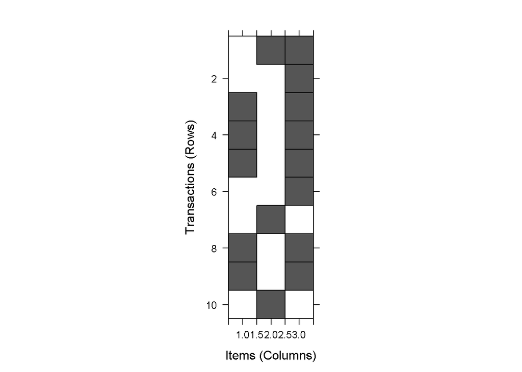

```r
trans_list <- read.transactions("mras_long.csv",format="single",sep=",",
                                cols=c("TID","ITEM"))
image(trans_list)
```

```r
new_rules <- apriori(trans_list, parameter=list(conf=0.0,supp=0.0))
```

```
## Apriori
##
## Parameter specification:
##  confidence minval smax arem  aval originalSupport support minlen maxlen
##           0    0.1    1 none FALSE            TRUE       0      1     10
##  target   ext
##   rules FALSE
##
## Algorithmic control:
##  filter tree heap memopt load sort verbose
##     0.1 TRUE TRUE  FALSE TRUE    2    TRUE
##
## Absolute minimum support count: 0
```

```
## set item appearances ...[0 item(s)] done [0.00s].
## set transactions ...[3 item(s), 10 transaction(s)] done [0.00s].
## sorting and recoding items ... [3 item(s)] done [0.00s].
## creating transaction tree ... done [0.00s].
## checking subsets of size 1 2 done [0.00s].
## writing ... [9 rule(s)] done [0.00s].
## creating S4 object  ... done [0.00s].
```

```r
new_rules.sorted <- sort(new_rules, by="lift")
inspect(new_rules.sorted)
```

```
##   lhs            rhs         support confidence lift
## 8 {Chicken}   => {Tacos}     0.5     1.0000000  1.2500000
## 9 {Tacos}     => {Chicken}   0.5     0.6250000  1.2500000
## 1 {}          => {Ice Cream} 0.3     0.3000000  1.0000000
## 2 {}          => {Chicken}   0.5     0.5000000  1.0000000
## 3 {}          => {Tacos}     0.8     0.8000000  1.0000000
## 7 {Tacos}     => {Ice Cream} 0.1     0.1250000  0.4166667
## 6 {Ice Cream} => {Tacos}     0.1     0.3333333  0.4166667
## 4 {Ice Cream} => {Chicken}   0.0     0.0000000  0.0000000
## 5 {Chicken}   => {Ice Cream} 0.0     0.0000000  0.0000000
```

# The Voting Record Again

We can also run the algorithm with significantly less preprocessing.

```r
data <- read.table("https://archive.ics.uci.edu/ml/machine-learning-databases/voting-records/house-votes-84.data", sep=",")
names(data) <- c("party","handicapped-infants",
                  "water-project-cost-sharing",
                  "adoption-of-the-budget-resolution",
                  "physician-fee-freeze",
                  "el-salvador-aid",
                  "religious-groups-in-schools",
                  "anti-satellite-test-ban",
                  "aid-to-nicaraguan-contras",
                  "mx-missile",
                  "immigration",
                  "synfuels-corporation-cutback",
                  "education-spending",
                  "superfund-right-to-sue",
                  "crime",
                  "duty-free-exports",
                  "export-administration-act-south-africa")
rules <- apriori(data,parameter=list(conf=0.95,supp=(0.3)))
```

```
## Apriori
##
## Parameter specification:
##  confidence minval smax arem  aval originalSupport support minlen maxlen
##        0.95    0.1    1 none FALSE            TRUE     0.3      1     10
##  target   ext
##   rules FALSE
##
## Algorithmic control:
##  filter tree heap memopt load sort verbose
##     0.1 TRUE TRUE  FALSE TRUE    2    TRUE
##
## Absolute minimum support count: 130
##
## set item appearances ...[0 item(s)] done [0.00s].
## set transactions ...[50 item(s), 435 transaction(s)] done [0.00s].
## sorting and recoding items ... [33 item(s)] done [0.00s].
## creating transaction tree ... done [0.00s].
## checking subsets of size 1 2 3 4 5 6 7 done [0.01s].
## writing ... [987 rule(s)] done [0.00s].
## creating S4 object  ... done [0.00s].
```

```r
rules.sorted <- sort(rules, by="lift")
inspect(head(rules.sorted, 10))
```

```
##    lhs                                      rhs                        support confidence     lift
## 1  {physician-fee-freeze=y,
##     synfuels-corporation-cutback=n}      => {party=republican}       0.3103448  0.9782609 2.532997
## 2  {adoption-of-the-budget-resolution=n,
##     physician-fee-freeze=y,
##     el-salvador-aid=y}                   => {party=republican}       0.3149425  0.9716312 2.515831
## 3  {adoption-of-the-budget-resolution=n,
##     physician-fee-freeze=y,
##     mx-missile=n}                        => {party=republican}       0.3011494  0.9703704 2.512566
## 4  {adoption-of-the-budget-resolution=n,
##     physician-fee-freeze=y,
##     crime=y}                             => {party=republican}       0.3057471  0.9637681 2.495471
## 5  {adoption-of-the-budget-resolution=n,
##     physician-fee-freeze=y}              => {party=republican}       0.3218391  0.9589041 2.482877
## 6  {physician-fee-freeze=y,
##     education-spending=y}                => {party=republican}       0.3080460  0.9503546 2.460740
## 7  {party=republican,
##     el-salvador-aid=y,
##     education-spending=y}                => {physician-fee-freeze=y} 0.3011494  1.0000000 2.457627
## 8  {party=republican,
##     el-salvador-aid=y,
##     superfund-right-to-sue=y}            => {physician-fee-freeze=y} 0.3034483  1.0000000 2.457627
## 9  {party=republican,
##     el-salvador-aid=y,
##     duty-free-exports=n}                 => {physician-fee-freeze=y} 0.3103448  1.0000000 2.457627
## 10 {party=republican,
##     el-salvador-aid=y}                   => {physician-fee-freeze=y} 0.3586207  0.9936306 2.441973
```